# Mathematical Programming/Optimization, Part 1

PSTAT 134 (Winter 2026)

Author

Affiliation

Sang-Yun Oh

University of California, Santa Barbara

## Mathematical Programming in Data Science

- Data science is often about finding the best solution to a problem.
- Mathematical programming/optimization is a research area for formulating and solving such problems.
- Key components of a mathematical programming problem:
- **Objective Function**: a quantity to be maximized or minimized.
  - defines what “best” means (e.g., profit, cost, error)
- **Decision Variables**: one or more variables that determine the outcome.
  - e.g., quantity of products to produce, parameters of a model
- **Constraints**: restrictions that qualify possible solutions.
  - e.g., resource capacity, time

## Example: OLS as Unconstrained Optimization

OLS[^1] finds the **best-fitting line** to minimize **$L^2$ norm** of residuals:
$$\min _{\beta_0, \beta_1} \sum_{i=1}^n\left(y_i-\beta_0-\beta_1 x_i\right)^2 = \min _\beta\|\mathbf{y}-\mathbf{X} \boldsymbol{\beta}\|_2^2,$$
where data is $(y_i, x_i)$ and $i=1,\ldots,n$.

. . .

- Objective function: $\|\mathbf{y}-\mathbf{X} \boldsymbol{\beta}\|_2^2$ ($L^2$-norm of errors)
- Decision variables: $\boldsymbol{\beta} = (\beta_0, \beta_1)'$
- Constraints: None ($\beta_0, \beta_1$ can take any real values)
- OLS is an unconstrained optimization problem.

## An Alternate Objective Function: Median Regression

What if objective function is a 1-norm, $\| v \|_1$?

. . .

$$\min _\beta\|\mathbf{y}-\mathbf{X} \boldsymbol{\beta}\|_1 = \min _{\beta_0, \beta_1} \sum_{i=1}^n |y_i-\beta_0-\beta_1 x_i|$$

where data is $(y_i, x_i)$ and $i=1,\ldots,n$.

. . .

What if objective is $\| v \|_\infty = \max_i |v_i|$ or $L^p$-norm?

. . .

$$\| v \|_p = \left(\sum_{i=1}^d |v_i|^p\right)^{1/p}$$

## OLS vs. Median Regression

**Solve Lp regression for p=1, 2, and infinity**

```python
# Create polynomial design matrix
poly_degree = 5

def build_poly_features(x, degree):
    return np.column_stack([x**k for k in range(degree + 1)])

X_design = build_poly_features(X, poly_degree)

def solve_Lp_regression(X_design, y, p=2):
    """
    Solve Lp regression using cvxpy.
    Minimizes: ||X*beta - y||_p
    """
    beta = cp.Variable(X_design.shape[1])
    objective = cp.Minimize(cp.norm(X_design @ beta - y, p))
    problem = cp.Problem(objective)
    problem.solve(verbose=False)
    return beta.value, problem.value

beta_L2, obj_L2 = solve_Lp_regression(X_design, y, p=2)
beta_L1, obj_L1 = solve_Lp_regression(X_design, y, p=1)
beta_Li, obj_Li = solve_Lp_regression(X_design, y, p="inf")
```

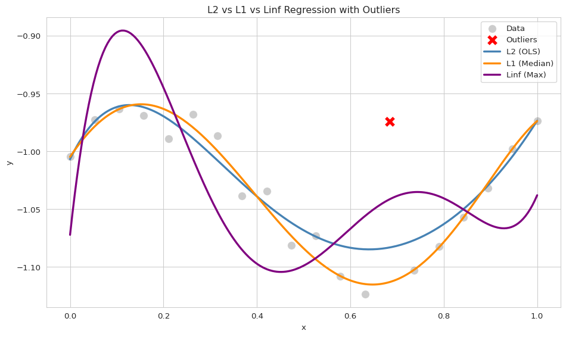

## Objective Function and Norms

- $L^1$ is robust to extreme points
- $L^\infty$ is more sensitive to extreme points
  - $L^\infty$-regression tries to minimize the maximum error.
  - e.g., minimize expected worst-case service times
- $L^2$ is a compromise between the two.

. . .

**Choice of objective function is crucial in defining an optimization problem**

- Changes the meaning of what is the “best”
- Changing the objective function leads to different solutions

## What about Constraints?

What if we add constraints on $\beta$?

- $\beta_0 = 0$: line must pass through the origin
- $\beta_1\geq 0$: only consider non-negative sloped line.
- $\|\beta\|_\leq c$ means only consider lines with small coefficients
  - $\|\beta\|_1\leq c$: Lasso constraint
  - $\|\beta\|_2\leq c$: Ridge constraint
  - $\|\beta\|_\infty\leq c$: coefficients are bounded by $c$

. . .

## Specifying constrained optimization problems

- OLS with $\beta_0 = 0$ constraint can be written as
  $$\min_\beta \|\mathbf{y}-\mathbf{X} \boldsymbol{\beta}\|_2^2 \;\text{ subject to }\; \beta_0 = 0$$
- Median regression with $\beta_1 \geq 0$ constraint can be written as
  $$\min_\beta \|\mathbf{y}-\mathbf{X} \boldsymbol{\beta}\|_1 \;\text{ subject to }\; \beta_1 \geq 0$$
- OLS with lasso constraint $\|\beta\|_1 \leq c$ can be written as
  $$\min_\beta \|\mathbf{y}-\mathbf{X} \boldsymbol{\beta}\|_2^2 \;\text{ subject to }\; \|\boldsymbol{\beta}\|_1 \leq c$$

. . .

Many statistical/ML models can be expressed as mathematical programming problems

## Principal Component Analysis (PCA) as Optimization

For centered data matrix $X\in \mathbb{R}^{n \times p}$ ($n$ observations and $p$ variables).

First PC loading vector $v_1$ can be obtained by solving,

$$\begin{aligned}
\max _{v_1} &\quad v_1^T X^T X v_1,\\
\text{subject to} &\quad v_1^T v_1=1 \quad \text{(length constraint)}
\end{aligned}$$

. . .

Second PC loading vector $v_2$ can be obtained by solving,
$$\begin{aligned}
\max _{v_2} &\quad v_2^T X^T X v_2,\\
\text{subject to} &\quad v_2^T v_2=1 \quad \text{(length constraint)} \\
&\quad v_2^T v_1=0 \quad \text{(orthogonality constraint)}
\end{aligned}$$

## PCA as Optimization (contd.)

The $k$-th PC loading vector $v_k$ can be obtained by solving,
$$\begin{aligned}
\max _{v_k} &\quad v_k^T X^T X v_k, & \\
\text{subject to} &\quad v_k^T v_k=1 \quad \text{(length constraint)} \\
&\quad v_j^T v_k=0, j=1, \ldots, k-1 \\
&\quad \text{(orthogonality constraint)}
\end{aligned}$$

. . .

Connection to SVD of $X = U\Sigma V^T$:

$$n S=X' X=\left(U \Sigma V'\right)'\left(U \Sigma V'\right)=V \Sigma^2 V'$$

. . .

Thus, $v_k$ is the $k$-th right singular vector of $X$ corresponding to the $k$-th largest singular value $\sigma_k$.

## General Mathematical Programming/Optimization

**Definition: Mathematical Programming/Optimization**

A *mathematical programming/optimization* problem has the form

$$\begin{array}{ll}
\operatorname{minimize}_x & f_0(x) \\
\operatorname{subject to} & f_i(x) \leq b_i, \quad i=1, \ldots, m
\end{array}$$

- Optimization variable: $x=\left(x_1, \ldots, x_n\right)$
- Objective function: $f_0: \mathbf{R}^n \rightarrow \mathbf{R}$
- Constraints: $f_i: \mathbf{R}^n \rightarrow \mathbf{R}$, $i=1, \ldots, m$
- Constraint limits/bounds: $b_1, \ldots, b_m$

. . .

A vector $x^{\star}$ is optimal for the problem, any $z$ with $f_1(z) \leq b_1, \ldots, f_m(z) \leq b_m$, we have
$$f_0\left(x^{\star}\right) \leq f_0(z).$$

## Linear Programming Problem

**Definition: Linear Programming Problem**

Optimization problem is called a *linear program* if the objective and constraint functions $f_0, \ldots, f_m$ are linear, i.e., satisfy

$$f_i(\alpha x+\beta y)=\alpha f_i(x)+\beta f_i(y)$$

for all $x, y \in \mathbf{R}^n$ and all $\alpha, \beta \in \mathbf{R}$.

. . .

Does $f(x) = a x + b$ qualify as linear? (assume $x$ is scalar)

. . .

Strictly speaking, $f(x) = a x + b$ is *affine* whereas $f(x) = a x$ is *linear*

**Example: Linear Programming Problem**

$$\begin{aligned}
\text{maximize}_{\left(x_1, x_2\right) \in \mathbb{R}^2}\quad & x_1+x_2\\
\operatorname{subject to}\quad & x_1 \geq 0,\, x_2 \geq 0 \\
& x_2-x_1 \leq 1 \\
& x_1+6 x_2 \leq 15 \\
& 4 x_1-x_2 \leq 10
\end{aligned}$$

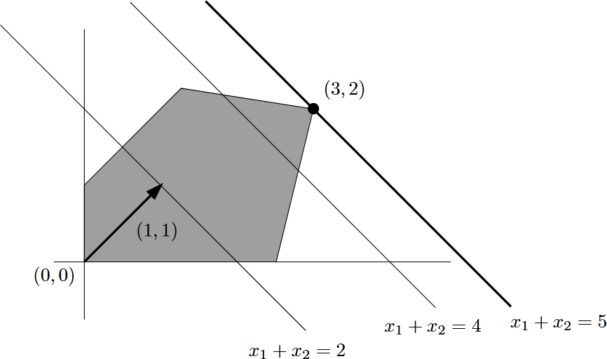

LP objective

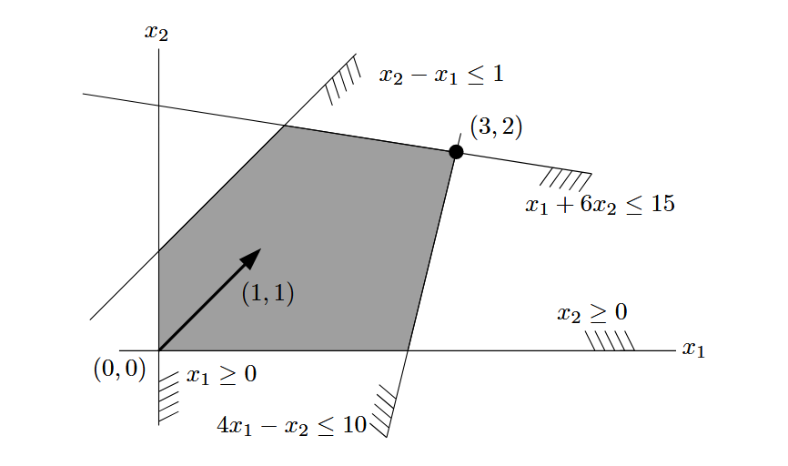

LP feasible region

## Nutrition Problem

Pick ingridients to fulfill nutritional requirements while minimizing cost

. . .

| Food | Carrot, Raw | White Cabbage, Raw | Cucumber, Pickled | Required |
| --- | --- | --- | --- | --- |
| Vitamin A (mg/kg) | 35 | 0.5 | 0.5 | 0.5 mg |
| Vitamin C (mg/kg) | 60 | 300 | 10 | 15 mg |
| Dietary Fiber (g/kg) | 30 | 20 | 10 | 4 g |
| price ($/kg) | 0.75 | 0.5 | 0.15 | - |

. . .

- Variables: $x_1$ (carrot), $x_2$ (cabbage), and $x_3$ (cucumber)
- Objective (cost): $0.75 x_1+0.5 x_2+0.15 x_3$
- Vitamin A: $35 x_1+0.5 x_2+0.5 x_3 \geq 0.5$
- Vitamin C: $60 x_1+300 x_2+10 x_3 \geq 15$
- Fiber: $30 x_1+20 x_2+10 x_3 \geq 4$

## Nutrition Problem: Matrix Form

$$\begin{array}{ll}
\text { minimize } & 0.75 x_1+0.5 x_2+0.15 x_3 \\
\text { subject to } & x_1 \geq 0,\, x_2 \geq 0,\, x_3 \geq 0 \\
& 35 x_1+0.5 x_2+0.5 x_3 \geq 0.5 \\
& 60 x_1+300 x_2+10 x_3 \geq 15 \\
& 30 x_1+20 x_2+10 x_3 \geq 4
\end{array}$$

. . .

- Define $c= (0.75, 0.5, 0.15)'$ and $x = (x_1, x_2, x_3)'$
- Define matrix $A$ and $b$ such that
- $\operatorname{minimize}_x c'x\; \operatorname{ subject to } Ax \leq b$

## General Form of LP

Rewriting the standard form of LP explicitly,

$$\begin{aligned}
&\begin{array}{ll}
\text { maximize the value of } & \mathbf{c}^T \mathbf{x} \\
\text { among all vectors } \mathbf{x} \in \mathbb{R}^n \text { satisfying } & A \mathbf{x} \leq \mathbf{b},
\end{array}\\
\quad \\
=
&\begin{array}{ll}
\text { maximize } & \mathbf{c}^T \mathbf{x} =c_1 x_1+c_2 x_2+\cdots+c_n x_n \\
\text { subject to } & a_{11} x_1+a_{12} x_2+\cdots+a_{1 n} x_n \leq b_1 \\
& a_{21} x_1+a_{22} x_2+\cdots+a_{2 n} x_n \leq b_2 \\
& \vdots \\
& a_{m 1} x_1+a_{m 2} x_2+\cdots+a_{m n} x_n \leq b_m
\end{array}
\end{aligned}$$

## Standard Form of LP

**Standard Form of LP**

A linear program can be written in the following standard form:

$$\begin{array}{ll}
\text { Maximize the value of } & \mathbf{c}^T \mathbf{x} \\
\text { among all vectors } \mathbf{x} \in \mathbb{R}^n \text { satisfying } & A \mathbf{x} \leq \mathbf{b},
\end{array}$$

where $A$ is a given $m \times n$ real matrix and $\mathbf{c} \in \mathbb{R}^n, \mathbf{b} \in \mathbb{R}^m$ are given vectors. Here inequality holds for two vectors of equal length if and only if it holds componentwise.

Any vector $\mathbf{x} \in \mathbb{R}^n$ satisfying all constraints of a given linear program is a **feasible solution**. Each $\mathbf{x}^* \in \mathbb{R}^n$ that gives the maximum possible value of $\mathbf{c}^T \mathbf{x}$ among all feasible $\mathbf{x}$ is called an **optimal solution**, or optimum for short.

## Example: Linear Program in cvxpy

**Solve the linear program with cvxpy**

```python
import cvxpy as cp

# Decision variables
x = cp.Variable(3, nonneg=True)
c = np.array([0.75, 0.5, 0.15])
A = np.array([
      [35, 0.5, 0.5],
      [60, 300, 10],
      [30, 20, 10],
      [1, 0, 0],
      [0, 1, 0],
      [0, 0, 1],
    ])
b = np.array([0.5, 15, 4, 0, 0, 0])

objective = cp.Minimize(0.75 * x[0] + 0.5 * x[1] + 0.15 * x[2])
constraints = [ -A @ x <= -b ]

problem = cp.Problem(objective, constraints)
problem.solve(verbose=False);
```

$\operatorname{minimize}_{x} \quad \mathbf{c}^T \mathbf{x} \; \operatorname{ subject to} \quad -A\mathbf{x} \leq -\mathbf{b}, \quad \mathbf{x} \geq \mathbf{0}$

. . .

Numerical solution is:

```
status: optimal
optimal value (cost): 0.070511
x* (amounts): [0.00952634 0.03826503 0.2948909 ]
constraints (feasibility): [5.00000001e-01 1.50000000e+01 4.00000000e+00 9.52634382e-03
 3.82650346e-02 2.94890899e-01]
```

## LP Exception Cases

- When a linear program has no feasible solutions, it is called **infeasible**.
- When a linear program has feasible solutions but can be arbitrarily large in value, it is called **unbounded**.
- When a linear program has feasible solutions and an optimal solution, but the optimal solution is not unique, it is called **degenerate**.

## LP Exception Cases: Unboundedness

$$\begin{aligned}
\max_{(x_1,x_2)\in\mathbb{R}^2}\; &\; x_1 \\
\text { subject to }\; &\; x_1-x_2 \leq 1 \\
& -x_1+x_2 \leq 2 \\
& x_1, x_2 \geq 0
\end{aligned}$$

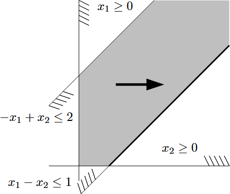

LP unboundedness

## LP Exception Cases: Degeneracy

$$\begin{aligned}
\max_{(x_1,x_2)\in\mathbb{R}^2}\; &\; x_2 \\
\text { subject to }\; &\; -x_1+x_2 \leq 0 \\
& x_1 \leq 2 \\
& x_1, x_2 \geq 0
\end{aligned}$$

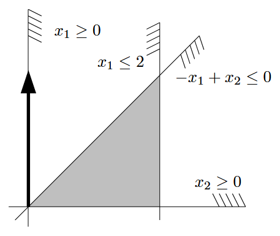

LP degeneracy

## Convex Optimization Problem

**Linear Programming Problem**

Optimization problem is called a *linear program* if the objective and constraint functions $f_0, \ldots, f_m$ are linear, i.e., satisfy

$$f_i(\alpha x+\beta y)=\alpha f_i(x)+\beta f_i(y)$$

for all $x, y \in \mathbf{R}^n$ and all $\alpha, \beta \in \mathbf{R}$.

. . .

**Convex Optimization Problem**

A *convex optimization* problem is one in which the objective and constraint functions are convex, which means they satisfy the following inequality:

$$f_i(\alpha x+\beta y) \leq \alpha f_i(x)+\beta f_i(y)$$

for all $x, y \in \mathbf{R}^n$ and all $\alpha, \beta \in \mathbf{R}$ with $\alpha+\beta=1, \alpha \geq 0, \beta \geq 0$.

## Footnotes

[^1]: Can you convert to matrix form?